# R tutorial China: Traits

Julia Chacón

21/2/2020

### Trait Distributions

#### Data wrangling

Here is the code for plotting the traits distributions. Before ploting the trait ditributions, we need to make some changes to the datasets and log transform the variables, to finally merge the two trait data sets into a single one.

First, you can see that Site is stored as “character”.

```r
mode(traitsLeaf$Site)
```

```
#> [1] "character"
```

Step 1: For plotting purpuses is better to transform this variable to a factor, with four levels (“L”, “M”, “A”, “H”). We will also log transform the traits, this will help to reduce the skewness of the values and to make the relationships between traits clearer.

```r
traitsWideL <- traitsLeaf %>%
  mutate(Wet_Mass_g.log = log(Wet_Mass_g),
         Dry_Mass_g.log = log(Dry_Mass_g),
         Leaf_Thickness_Ave_mm.log = log(Leaf_Thickness_Ave_mm),
         Leaf_Area_cm2.log = log(Leaf_Area_cm2)) %>%
  mutate(Site = factor(Site, levels = c("L", "M", "A", "H")))
```

Step 2: New format to the leaf traits data, with traits and values in two columns:

```r
traitsLongL <- traitsWideL %>%
  select(Date, Elevation, Site, Treatment, Taxon, Individual_number, Leaf_number, Wet_Mass_g.log, Dry_Mass_g.log, Leaf_Thickness_Ave_mm.log, Leaf_Area_cm2.log, SLA_cm2_g, LDMC) %>%
  pivot_longer(cols=c("Wet_Mass_g.log", "Dry_Mass_g.log", "Leaf_Thickness_Ave_mm.log", "Leaf_Area_cm2.log", "SLA_cm2_g", "LDMC"), names_to="Traits", values_to = "Value")
```

Step 3: New format to the leaf Chemical traits (same manner). These values are percentage, so we don´t need to log transform these traits:

```r
traitsLongC <- traitsChem %>%
  select(Date, Elevation, Site, Treatment, Taxon, P_percent, C_percent, N_percent, CN_ratio, dN15_percent, dC13_percent) %>%
  pivot_longer(cols=c("P_percent", "C_percent","N_percent", "CN_ratio", "dN15_percent", "dC13_percent"), names_to="Traits", values_to = "Value")
```

Step 4: Bind the two data sets (Leaf and Chemical traits), using the two “long” tables:

```r
traitsLong <- traitsLongL %>% bind_rows(traitsLongC)
```

Make the Site a factor instead of a character, and order the levels from L to H (upslope)

```r
traitsLong <- traitsLong %>%
  mutate(Site = factor(Site, levels = c("L", "M", "A", "H")))
```

A short note:

Reasons for mutating character names into a factor (or why sometimes is better to use factor instead of character in R): This is not 100% neccesary and you can load the upcomming codes without mutating the Traits names into a factor, so no worries too much about this lines. But here is the explanation. Factors are stored as numbers (integers) and have labels associated with these unique numbers (the values or names you assigned) and a table of levels. This saves a lot of memory compared to character. In case you are working with categorical data (predifined, finite number of values) is generally better to use factors instead of character. Although factors look like as character vectors they are integers in their “heart”. They are stored in alphabetical order or we can define a meaningfull order (as we did with Site or will do with the Traits names). Compared to simple integers (1,2,3,4), factors are “self-describing” (“L”,“M”,“A”,“H”).

#### Density plot

Here is the code to plot the traits distributions, using density plots. A density plot is similar to an histogram, and allows visualizing the distribution of a numerical variable (it shows the interval and the peaks of the distribution). The peaks of a density plot show where the values are concentrated over the interval.

We want to plot the distribution of each invidual trait, at each site, to visualize their variation. So, first we filter the values containing NA´s, since we are not interested in that and transform the Traits names into a factor (they are stored as character). Then, we plot it using ggplot. The values of each trait are going to appear in the x coordinate (Value) and their frequency in coordinate y. Density curves appear on different colors based on the Site (fill=Site).

`geom_density(alpha = 0.5)´ argument simply fills the density curves with a transparent color.

`facet_wrap´ argument allows spliting the plot into the different Traits

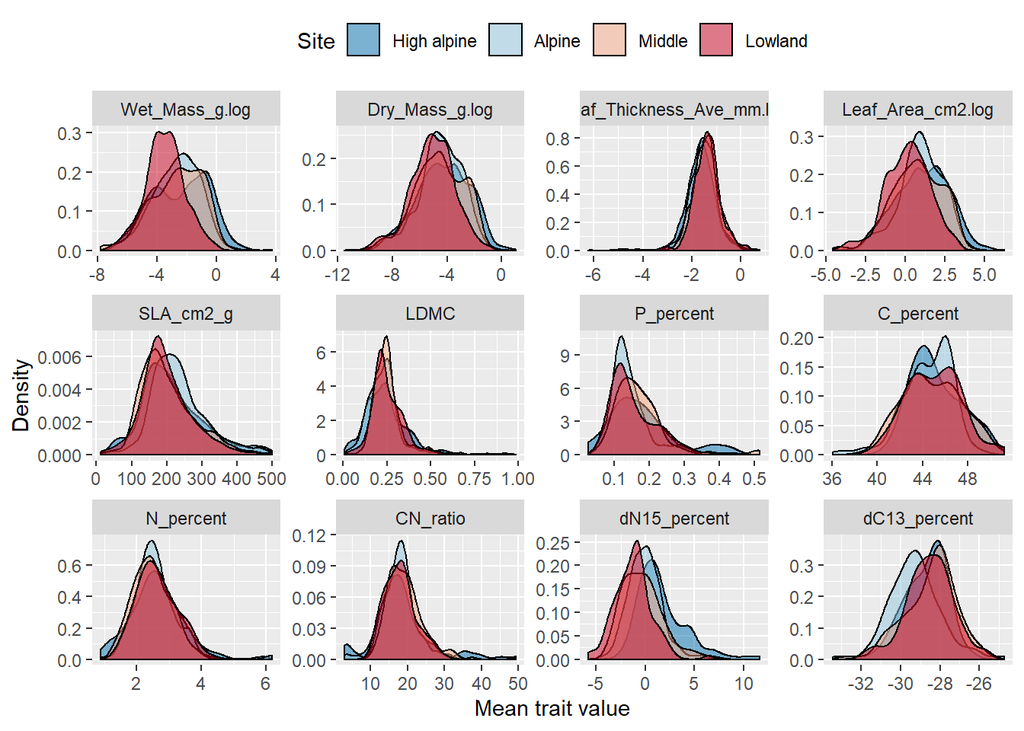

```r
TraitDist <- traitsLong %>%
  filter(!is.na(Value)) %>%
  mutate(Traits = factor(Traits, levels = c("Wet_Mass_g.log", "Dry_Mass_g.log", "Leaf_Thickness_Ave_mm.log", "Leaf_Area_cm2.log", "SLA_cm2_g", "LDMC", "P_percent", "C_percent", "N_percent", "CN_ratio", "dN15_percent", "dC13_percent"))) # if you don´t understand why we are mutating Traits into a factor, you can just remove the last part of this code. It won´t make a huge difference.

TraitDist.plot <- ggplot(TraitDist, aes(x = Value, fill = Site)) +
  geom_density(alpha = 0.5) +
  scale_fill_brewer(palette = "RdBu", direction = -1, labels=c("High alpine", "Alpine", "Middle", "Lowland")) +
  labs(x = "Mean trait value", y = "Density") +
  facet_wrap( ~ Traits, scales = "free") +
  theme(legend.position="top")

TraitDist.plot
```

Exercise:

Try to plot the same density plot, but using only the values of one of the treatments. For example, only the “LOCAL” values, or the “OTC” values.

#### Boxplots

A different way of displaying the distribution of the data is using boxplots. Boxplots are a graph showing how the values are spread out, similarly to the density plots. Sometimes boxplots are more informative that other measures of central tendencies like the mean. We are using here the object TraitDist, defined before.

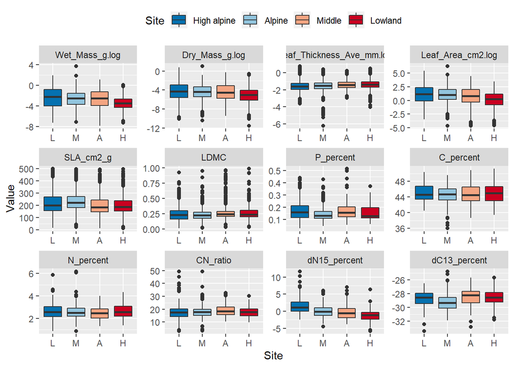

```r
TraitBoxp.plot <- ggplot(TraitDist, aes(x=Site, y = Value, fill = Site)) +
 geom_boxplot() +
 scale_fill_brewer(palette = "RdBu", direction = -1, labels=c("High alpine", "Alpine", "Middle", "Lowland")) +
  facet_wrap( ~ Traits, scales = "free") +
  theme(legend.position="top")

TraitBoxp.plot
```

### Traits scatterplots

#### Data wrangling

This are just some scatterplots relating 2 traits values. Each dot is an observation, and each coordinate represent the value of each of the traits. Fitting traits again each other is very usefull to detect outliers and weird relationships that could indicate an error or outliers in the dataset.

Some expamples of scatterplots:

```r
DryWet <- traitsWideL %>%
  ggplot(aes(x = Dry_Mass_g.log, y = Wet_Mass_g.log, colour = Site)) +
  geom_point(alpha = 0.4) +
  scale_color_brewer(palette = "RdBu", direction = -1, labels=c("High alpine", "Alpine", "Middle", "Lowland")) +
  theme(legend.position = "none")
```

```r
DryArea <- DryWet + aes(x = Dry_Mass_g.log, y = Leaf_Area_cm2.log) +
  theme(legend.position = "right")
AreaSLA <- DryWet + aes(x = Leaf_Area_cm2, y = SLA_cm2_g)
LDMCThick <- DryWet + aes(x = LDMC, y = Leaf_Thickness_Ave_mm)
```

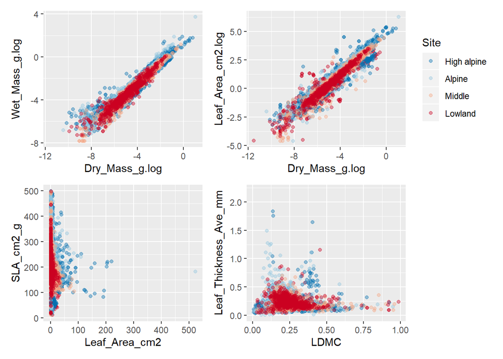

```r
DryWet + DryArea + AreaSLA + LDMCThick
```

### Traits means

We want to plot the mean values and standard error of each invidual trait, at each site, and for each treatment separately. In the plots that we did before we did not differenciate between treatments, but now we do. We are going to use again “traitsLong” object

#### Plot of the means per trait

Plotting the mean values and standard errors for each trait, per site and treatment.

Step 1: Summarize the data from traitsLong. The next code, will make a summary table with the mean values, stardard deviation and stardard errors, grouping the column Value, by Trait, Treatment and Site.

I have excluded the values of “outexp” (data from outside the experimental turfs)

```r
TraitsSE <- traitsLong %>%
  filter(!is.na(Value)) %>%
  filter(Treatment!= "outexp") %>%
  group_by(Site, Treatment, Traits) %>%
  summarize(N = length(Value), mean = mean(Value), sd = sd(Value), se = sd / sqrt(N))
```

Step 2: Make the plot. Define first the position_dodge, this argument allow you to move horizontaly the errors bars, so they don´t overlap. Exercise: see what happens if you don´t define the position_dodge, or try to change the value.

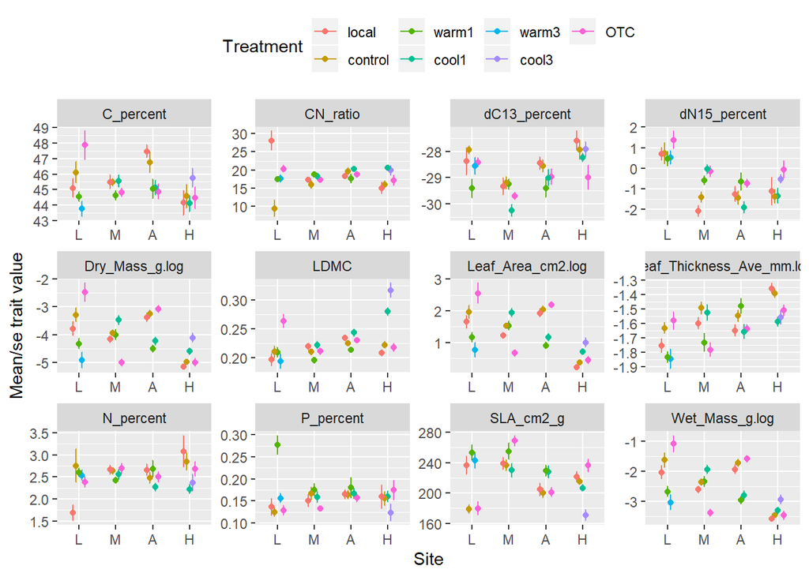

```r
pd <- position_dodge(0.4)

TraitsSE.p <- ggplot(TraitsSE, aes(x = Site, y=mean,  colour=Treatment)) +
  geom_errorbar(aes(ymin=mean-se, ymax=mean+se), width=.1, position=pd) +
  geom_line(position=pd) +
  geom_point(position=pd)+
  labs(x = "Site", y = "Mean/se trait value") +
  facet_wrap( ~ Traits, scales = "free") +
  theme(legend.position="top")

TraitsSE.p
```

For saving the plot:

```r
ggsave(TraitsSE.p, filename = "TraitSE.jpg", height = 13, width = 13, dpi = 300)
```

### Community weighted means

Calculation of community weighted means. An ‘easy’ (and not very meaningful) example using only data from 2012 and the Control plots.

#### Data wrangling

For the traits calculations we are going to use traitsLong, you can check how we built this data frame in the previous codes. Now, just select the variables Site, Treatment, Taxon, Traits and Value to manage a smaller set of data.

```r
traitsLong <- traitsLong %>%
  select(Site, Treatment, Taxon, Traits, Value) %>%
  mutate(Site= factor(Site, levels=c("L", "M", "A","H")))
```

##### Calculate mean trait values

And calculate the mean trait values for each taxon per site. Trait values can be assign in different ways. But now, we are going to use mean trait values per sites for simplicity.

```r
traits.meanvalues <- traitsLong %>%
  filter(!is.na(Value)) %>%
  group_by(Site, Traits, Taxon) %>%
  summarise(mean = mean(Value)) %>%
  spread(key = Traits, value = mean)
```

##### Calculate the weights

Subset the cover data, by year and treatment, to include only 2012 and Control plots. We are going to use the cover data of each species in each site as a “weight” for calculating the community weighted means.

```r
cover_2012C <- cover_thin %>%
  filter(year == "2012")%>% # subset the year
  filter(TTtreat =="control")%>% # subset the control
  select(originSiteID, originPlotID, turfID, TTtreat, year, cover, speciesName) # select only a few variables (we dont need everything)
```

Now, calculate the species weights based on mean cover of each species at each site in 2012 in the Control plots. Just a mean of the cover per site for each species!

```r
spp.wts2012C <- cover_2012C %>%
  group_by(originSiteID, speciesName) %>%
  summarise(wts = mean(cover))
```

Now, we need to merge the species weights with their mean trait values in a single data frame, and we are going to use the column “Taxon” to conect both data frame. But, the two data frames have different column names for the species names as you will see here:

```r
names(spp.wts2012C) # names of the columns or variables
```

```
#> [1] "originSiteID" "speciesName"  "wts"
```

```r
names(traits.meanvalues) # names of the columns or variables
```

```
#>  [1] "Site"                      "Taxon"
#>  [3] "C_percent"                 "CN_ratio"
#>  [5] "dC13_percent"              "dN15_percent"
#>  [7] "Dry_Mass_g.log"            "LDMC"
#>  [9] "Leaf_Area_cm2.log"         "Leaf_Thickness_Ave_mm.log"
#> [11] "N_percent"                 "P_percent"
#> [13] "SLA_cm2_g"                 "Wet_Mass_g.log"
```

So, first we are going to change the second column name in ssp.wts2012C and call it “Taxon”, and after that we can join the two tables.

```r
spp.wts2012C <- rename(spp.wts2012C, Taxon=speciesName)
spp.wts2012C <- rename(spp.wts2012C, Site=originSiteID)

# and then merge:
traits.wts <- merge(spp.wts2012C, traits.meanvalues, by=c("Taxon", "Site")) %>%
    arrange(Site)%>%
  mutate(Site= factor(Site, levels=c("L", "M", "A","H")))

traits.wtsL <- traits.wts %>%
pivot_longer(cols = c("C_percent", "CN_ratio","dC13_percent","dN15_percent", "Dry_Mass_g.log", "LDMC", "Leaf_Area_cm2.log", "Leaf_Thickness_Ave_mm.log", "N_percent", "P_percent", "SLA_cm2_g", "Wet_Mass_g.log"), names_to = "traits", values_to = "value")
```

There we go:

```r
cwm <- traits.wtsL %>%
group_by(Site, traits) %>%
  summarise(wm = weighted.mean(value, wts, na.rm=TRUE))
```

Step 2: Plot

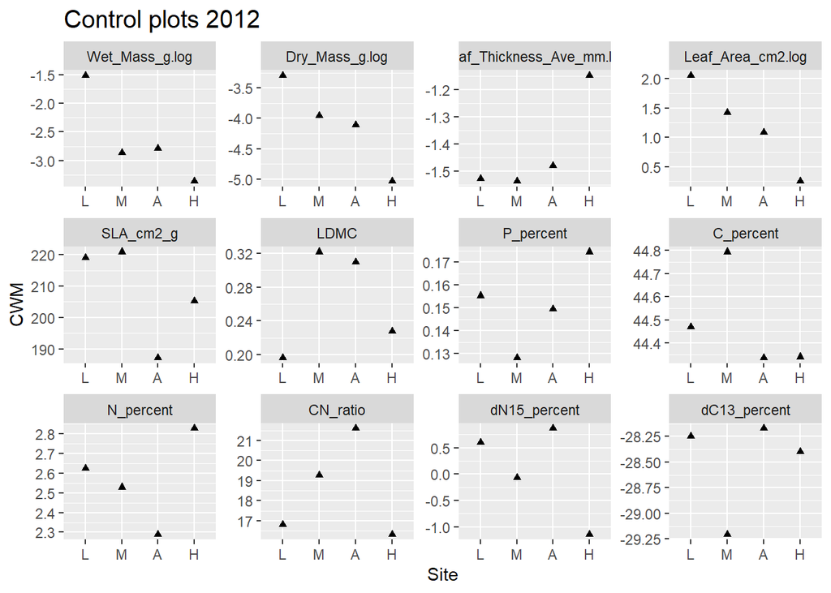

```r
pd <- position_dodge(0.4)

cwm.p <- cwm %>%
 mutate(traits = factor(traits, levels = c("Wet_Mass_g.log", "Dry_Mass_g.log", "Leaf_Thickness_Ave_mm.log", "Leaf_Area_cm2.log", "SLA_cm2_g", "LDMC", "P_percent", "C_percent", "N_percent", "CN_ratio", "dN15_percent", "dC13_percent")))

cwm.p = as.data.frame(cwm.p) #transform to a data frame

cwm.p <- ggplot(cwm.p, aes(x = Site, y= wm)) +
 geom_point(position=pd, shape=17) +
 labs(x = "Site", y = "CWM", title="Control plots 2012") +
 facet_wrap( ~ traits, scales = "free") +
 theme(legend.position="top", plot.title = element_text(size = (15)))

cwm.p
```